# Wind speed quantile mapping (QM)

**Problem.** DTN wind speed is corrupted from 7 Oct 2025 to 14 Apr 2026: the values are squashed (smaller amplitude, smoother) while the wind farms keep generating normally. Using the raw data would understate wind and break the wind proxy.

**Fix.** Quantile mapping per station. In the corrupted window, each half-hour keeps its *rank* but takes the *value* that rank has in clean reference years (same month and half-hour slot, FY23-25).

**Flow** 1. Set-up: load data (from `utilsData`), build the half-hourly (`hh`) and monthly (`mo`) tables, QM helper functions

2. Evidence that the data is corrupted
3. Is QM feasible, and when does the corruption start?
4. QM for stations 89002 and 86338
5. Validation: proxy CF vs actual CF, and a simulation on clean winters
6. Extend the correction to 1-14 April
7. Save the corrected weather file
8. Summary figures

**Output:** `data/processed/QM_HistoricWeather_30min.csv`.

## 1. Set-up

```python
# =============================================================================
# CELL 1.1 -- Imports, configuration and data loading
# Imports libraries and the project functions, sets the data folder, defines `cfg`
# (analysis window, wind and solar assets, weather stations) and loads the data.
# Generation (MLF- and capacity-scaled) and half-hourly weather come from utilsData.
# apply_qm=False: this file needs the RAW DTN wind speed, because it creates the QM file.
# =============================================================================


# pip install numpy pandas matplotlib scipy pytz ipykernel

import os, sys, warnings

import numpy as np
import pandas as pd
import matplotlib.pyplot as plt

warnings.filterwarnings('ignore')

# Find the project root (the folder that contains 'functions/'),
# whether the cwd is the root (VS Code / Jupyter) or analysis/ (quarto render)
ROOT = next(p for p in [os.getcwd(), os.path.dirname(os.getcwd())]
            if os.path.isdir(os.path.join(p, 'functions')))
sys.path.append(os.path.join(ROOT, 'functions'))

from utilsData import load_generation_inputs, load_weather_history, build_targets, _to_naive_timestamp

DATA_DIR = os.path.join(ROOT, 'data')  # folder with raw/ and processed/

cfg = {
    'zero_dollar_floor': True,                    # floor prices at $0 when computing contract revenue
    'analysis_start': '2022-07-01 00:00:00',
    'analysis_end': '2026-06-30 23:30:00',
    'wind_assets': ['DUNDWF3', 'BRYB1WF1', 'BULGANA1', 'MRTLSWF1'],
    'solar_assets': ['WINTSF1', 'GLENSF1', 'COHUNSF1'],
    'station_ids': [85280, 86338, 89002],
    'nearest_station_by_asset': {                 # weather station used for each wind farm
        'DUNDWF3': 89002, 'BRYB1WF1': 89002, 'BULGANA1': 89002, 'MRTLSWF1': 86338,
    },
    'wind_csv': os.path.join(DATA_DIR, 'raw', 'HistoricWeather_30min.csv'),   # raw wind/temperature (not QM)
    'weather_interp_limit': 2,                    # max consecutive 30-min gaps to interpolate
}
print('Configuration done. Wind assets:', cfg['wind_assets'])

gen_scaled, vret_data, vret_capacity = load_generation_inputs(cfg, DATA_DIR)
weather_hh, weather_raw = load_weather_history(cfg, DATA_DIR, apply_qm=False)

print(f'Generation: {gen_scaled.shape}, Weather: {weather_hh.shape[0]} rows x {weather_hh.shape[1]} cols')
print(f'Period: {gen_scaled.index.min()} -> {gen_scaled.index.max()}')
```

```
Configuration done. Wind assets: ['DUNDWF3', 'BRYB1WF1', 'BULGANA1', 'MRTLSWF1']
Extending exclusions
...exclusion period 1 updated to COHUNSF1 2021-10-01 00:00:00 to 2022-03-31 00:00:00
...exclusion period 11 updated to COHUNSF1 2023-10-01 00:00:00 to 2023-10-31 00:00:00
...exclusion period 12 updated to COHUNSF1 2023-12-01 00:00:00 to 2023-12-31 00:00:00
...exclusion period 18 updated to COHUNSF1 2024-03-30 00:00:00 to 2025-04-30 00:00:00
...exclusion period 39 updated to COHUNSF1 2026-01-01 00:00:00 to 2026-01-31 00:00:00
...exclusion period 42 updated to COHUNSF1 2026-04-01 00:00:00 to 2026-06-30 00:00:00
...exclusion period 43 updated to WINTSF1 2024-07-01 00:00:00 to 2024-08-31 00:00:00
...exclusion period 44 updated to WINTSF1 2024-11-01 00:00:00 to 2025-01-07 00:00:00
...exclusion period 52 updated to BULGANA1 2024-06-01 00:00:00 to 2025-12-31 00:00:00
...exclusion period 53 updated to BULGANA1 2026-01-01 00:00:00 to 2026-02-03 00:00:00
...exclusion period 61 updated to BRYB1WF1 2022-02-01 00:00:00 to 2022-02-28 00:00:00
...exclusion period 64 updated to BRYB1WF1 2022-07-01 00:00:00 to 2022-07-31 00:00:00
...exclusion period 67 updated to MRTLSWF1 2022-06-30 00:00:00 to 2023-06-30 00:00:00
DUNDWF3 : 01-10-2021 to 13-08-2026 : 85343 30-min intervals
...data points filtered for commissioning & exclusions : 196 (0.0%)
BRYB1WF1 : 01-10-2021 to 13-08-2026 : 85343 30-min intervals
...data points filtered for commissioning & exclusions : 3078 (4.0%)
BULGANA1 : 01-10-2021 to 13-08-2026 : 85343 30-min intervals
...data points filtered for commissioning & exclusions : 30827 (36.0%)
MRTLSWF1 : 30-06-2022 to 13-08-2026 : 72280 30-min intervals
...data points filtered for commissioning & exclusions : 19259 (27.0%)
WINTSF1 : 01-10-2021 to 13-08-2026 : 85343 30-min intervals
...data points filtered for commissioning & exclusions : 6146 (7.0%)
GLENSF1 : 01-12-2023 to 13-08-2026 : 47368 30-min intervals
...data points filtered for commissioning & exclusions : 5849 (12.0%)
COHUNSF1 : 01-10-2021 to 13-08-2026 : 85343 30-min intervals
...data points filtered for commissioning & exclusions : 52258 (61.0%)
Generation: (70128, 8), Weather: 70128 rows x 33 cols
Period: 2022-07-01 00:00:00 -> 2026-06-30 23:30:00
```

```python
# =============================================================================
# CELL 1.2 -- Build the half-hourly (hh) and monthly (mo) tables
# proxy_func  proxy CF: same formula as the contract factor with the generation replaced by X_t
# hh          half-hourly: price, wind generation, wind speed (m/s) per station
# mo          monthly: contract factors from utilsData.build_targets (CF_WIND = fleet CF)
# lut_data    power-curve lookup per wind farm (median CF per 0.1 m/s bin, clean data only)
# =============================================================================


def proxy_func(x, p):
    """Proxy: same formula as CF, replacing generation with X_t."""
    return (x * p.clip(lower=0)).sum() / x.sum() / p.mean() if x.sum() > 0 else np.nan

# === Half-hourly table hh ===
hh = gen_scaled[['VIC1Price'] + cfg['wind_assets']].copy()
hh.columns = ['price'] + [f'gen_{a}' for a in cfg['wind_assets']]
for stn in cfg['station_ids']:
    hh[f'ws_{stn}'] = weather_hh[f'wind_speed_ms_{stn}']
hh['gen_wind'] = hh[[f'gen_{a}' for a in cfg['wind_assets']]].sum(axis=1, min_count=1)

# === Power-curve lookup tables: median actual CF per 0.1 m/s wind-speed bin ===
# Built from clean data only (the corruption period is excluded)
# Note: BULGANA1 lookup bakes in battery dispatch (charge/discharge pattern)
_corruption_range = ('2025-10-01', '2026-03-31')
lut_data = {}  # {asset: (ws_array, power_array)}
for a in cfg['wind_assets']:
    stn = cfg['nearest_station_by_asset'][a]
    _d = pd.DataFrame({'v': hh[f'ws_{stn}'],
                       'cf': hh[f'gen_{a}'] / (0.5 * vret_capacity[a])}).dropna()
    _clean = _d[~_d.index.to_series().between(*_corruption_range)]
    _bins = _clean.groupby(_clean['v'].round(1))['cf'].median()
    _bins = _bins[(_bins.index >= 0) & (_bins.index <= 22)]
    lut_data[a] = (_bins.index.values, _bins.values)

# === Monthly table mo ===
mo = build_targets(gen_scaled, cfg, vret_capacity)
mo['CF_WIND'] = mo['WIND_ContractFactor']

print(f'hh: {hh.shape}, mo: {mo.shape}')
print('Capacity (MW):', {k: round(float(v), 1) for k, v in vret_capacity.items()})
```

```
hh: (70128, 9), mo: (48, 87)
Capacity (MW): {'DUNDWF3': 121.0, 'BRYB1WF1': 178.3, 'BULGANA1': 176.6, 'MRTLSWF1': 110.6, 'WINTSF1': 85.2, 'GLENSF1': 82.0, 'COHUNSF1': 27.0, 'WIND': 586.5, 'SOLAR': 194.2}
```

```python
# =============================================================================
# CELL 1.3 -- QM helper functions and plot style
# Used by the QM and validation cells below:
#   qmap                  map corrupted values onto a reference distribution, keeping their rank
#   apply_qm              qmap applied group by group (calendar month x half-hour slot)
#   lut_cf                wind speed -> CF through a power-curve lookup table
#   lut_for_station       power curve used to test each station
#   climatology_ws        placebo wind speed built from clean-year averages
#   real_sd_ratios        measured squashing (sd corrupted / sd reference) per month
#   proxy_by_month        monthly proxy CF of several wind-speed versions vs the actual CF
#   simulate_qm_recovery  corrupt clean winters ourselves and measure how much QM recovers
#   add_titles, table_title  figure title + insight subtitle, table caption
# =============================================================================

from scipy.stats import rankdata

def qmap(bad_vals, ref_vals):
    """Map corrupted values onto the reference distribution, preserving rank order."""
    # Quantile level of each corrupted value within its own group (rank-based plotting position)
    q = (rankdata(bad_vals) - 0.5) / len(bad_vals)
    # Same quantile levels read off the clean reference distribution
    return np.quantile(ref_vals.dropna(), q)


def apply_qm(ws_bad, ws_all, ref_mask, min_bad=20, min_ref=50):
    """Quantile-map `ws_bad` group by group (calendar month x half-hour slot of the day).

    Args:
        ws_bad: Corrupted values to correct (Series, a subset of ws_all).
        ws_all: Full wind speed series; the reference values are taken from it.
        ref_mask: Boolean array over ws_all.index marking the clean reference half-hours.
        min_bad, min_ref: Minimum group sizes; smaller groups are left unchanged.

    Returns:
        (corrected Series on ws_bad.index, number of half-hours mapped,
         skipped groups as (month, slot, n_bad, n_ref)).
    """
    idx_all = ws_all.index
    slot_all = idx_all.hour * 2 + idx_all.minute // 30
    slot_bad = ws_bad.index.hour * 2 + ws_bad.index.minute // 30
    out = ws_bad.copy()
    n_mapped, skipped = 0, []
    for (m, s), g in ws_bad.groupby([ws_bad.index.month, slot_bad]):
        ref_vals = ws_all[ref_mask & (idx_all.month == m) & (slot_all == s)]
        # Skip groups too small to estimate quantiles
        if len(g) >= min_bad and len(ref_vals.dropna()) >= min_ref:
            out.loc[g.index] = qmap(g.values, ref_vals)
            n_mapped += len(g)
        else:
            skipped.append((m, s, len(g), len(ref_vals.dropna())))
    return out, n_mapped, skipped


def lut_cf(ws, lut):
    """CF (0-1) from wind speed through a power-curve lookup table (ws_array, power_array)."""
    lut_ws, lut_pw = lut
    return pd.Series(np.clip(np.interp(ws.values, lut_ws, lut_pw), 0, 1), index=ws.index)


def climatology_ws(ws, lut, bad, ref):
    """Placebo wind speed: corrupted half-hours get the wind speed whose CF equals the
    average CF of the same (month, slot) in the reference years; clean half-hours are kept.

    It uses no real weather information, so it shows what 'no information' scores.
    """
    idx = ws.index
    slot = idx.hour * 2 + idx.minute // 30
    lut_ws, lut_pw = lut
    fv_ref = lut_cf(ws[ref], lut)
    clim_lookup = fv_ref.groupby([idx[ref].month, slot[ref]]).mean()
    out = ws.copy()
    clim_fv_bad = clim_lookup.reindex(pd.MultiIndex.from_arrays([idx[bad].month, slot[bad]])).values
    out.iloc[np.where(bad)[0]] = np.interp(clim_fv_bad, lut_pw, lut_ws)   # inverse of the power curve
    return out


def real_sd_ratios(ws, bad, ref):
    """sd(corrupted) / sd(reference) for each month of the Oct-Mar season (0.3 if undefined)."""
    idx = ws.index
    ratios = {}
    for m in [10, 11, 12, 1, 2, 3]:
        b = ws[bad & (idx.month == m)].dropna()
        r = ws[ref & (idx.month == m)].dropna()
        ratios[m] = b.std() / r.std() if r.std() > 0 else 0.3
    return ratios


def proxy_by_month(versions, lut, bad, price, mo):
    """Monthly proxy CF of several wind-speed versions, compared with the actual WIND CF.

    Args:
        versions: Dict label -> wind speed Series (e.g. Corrupted, QM-corrected, Climatology).
        lut: Power-curve lookup table (ws_array, power_array).
        bad: Boolean array; the months touched by it are evaluated.
        price: Half-hourly price Series. mo: Monthly table with 'CF_WIND'.

    Returns:
        DataFrame with month, version, proxy, cf_actual and error (= proxy - actual).
    """
    idx = price.index
    rows = []
    for m_per in sorted(set(idx[bad].to_period('M'))):
        mm = (idx >= m_per.start_time) & (idx <= m_per.end_time)
        cf = mo.loc[mo.index.to_period('M') == m_per, 'CF_WIND'].values
        cf = cf[0] if len(cf) > 0 else np.nan
        for label, ws in versions.items():
            pf = proxy_func(lut_cf(ws[mm], lut), price[mm])
            rows.append({'month': m_per.strftime('%Y-%m'), 'version': label,
                         'proxy': pf, 'cf_actual': cf, 'error': pf - cf})
    return pd.DataFrame(rows)


def simulate_qm_recovery(ws, lut, sd_ratios, windows, ref_all, price):
    """Corrupt clean winters ourselves, run QM and measure the proxy CF error before/after.

    For each (label, start, end) window: squeeze the values towards the monthly median by
    `sd_ratios`, smooth with a 3-point moving average, apply QM with the other clean winters
    as reference (the simulated one is excluded), then compare monthly proxy CF with the truth.

    Returns:
        DataFrame with sim, month, proxy_true, proxy_fake_bad, proxy_recovered, err_bad, err_recov.
    """
    idx = ws.index
    rows = []
    for sim_label, sim_start, sim_end in windows:
        sim_mask = (idx >= sim_start) & (idx < sim_end)

        # Fake corruption
        ws_fake = ws[sim_mask].copy()
        for m in [10, 11, 12, 1, 2, 3]:
            m_mask = ws_fake.index.month == m
            if m_mask.sum() == 0:
                continue
            vals = ws_fake[m_mask]
            med = vals.median()
            # Keep the median, scale the deviation by the sd ratio
            ws_fake.loc[m_mask] = med + (vals - med) * sd_ratios[m]
        ws_fake = ws_fake.rolling(3, center=True, min_periods=1).mean().clip(lower=0)

        # QM with the simulated winter excluded from the reference
        ws_recovered, _, _ = apply_qm(ws_fake, ws, ref_all & ~sim_mask)

        for m_per in sorted(set(idx[sim_mask].to_period('M'))):
            mm = (idx >= m_per.start_time) & (idx <= m_per.end_time)
            p = price[mm]
            pf_true = proxy_func(lut_cf(ws[mm], lut), p)
            pf_fake = proxy_func(lut_cf(pd.Series(ws_fake.reindex(idx[mm]).values, index=idx[mm]), lut), p)
            pf_recov = proxy_func(lut_cf(pd.Series(ws_recovered.reindex(idx[mm]).values, index=idx[mm]), lut), p)
            rows.append({'sim': sim_label, 'month': m_per.strftime('%Y-%m'),
                         'proxy_true': pf_true, 'proxy_fake_bad': pf_fake, 'proxy_recovered': pf_recov,
                         'err_bad': abs(pf_fake - pf_true), 'err_recov': abs(pf_recov - pf_true)})
    return pd.DataFrame(rows)

def lut_for_station(stn):
    """Power-curve lookup for a station: the first farm that uses it as its nearest station,
    otherwise DUNDWF3 as a cross-check (different power curve, but QM effectiveness is still measurable).

    Returns (asset name, lookup table).
    """
    farms = [a for a in cfg['wind_assets'] if cfg['nearest_station_by_asset'].get(a) == stn]
    asset = farms[0] if farms else 'DUNDWF3'
    return asset, lut_data[asset]


# ── Plot style ──
GREY, ORANGE, BLUE, RED = '#888888', '#e67e22', '#391B56', '#c0392b'

import matplotlib as mpl
from IPython.display import Markdown


def add_titles(fig, title, subtitle=None):
    """Bold figure title with an optional one-line insight (subtitle) below it.

    Call after fig.tight_layout(); the text is placed just above the top of the figure.
    """
    def put(text, offset_pt, **kw):
        fig.add_artist(mpl.text.Annotation(text, xy=(0.5, 1.0), xycoords='figure fraction',
                                           xytext=(0, offset_pt), textcoords='offset points',
                                           ha='center', va='bottom', **kw))
    put(title, 8 + (16 if subtitle else 0), fontsize=12, fontweight='bold')
    if subtitle:
        put(subtitle, 6, fontsize=10, color='#555555', style='italic')


def table_title(title, note=None):
    """Print a bold table caption (and an optional italic note) above display(df)."""
    display(Markdown(f'**{title}**' + (f'  \n*{note}*' if note else '')))
```

## 2. Evidence of corruption

Measured wind speed falls outside its historical range while generation stays normal.

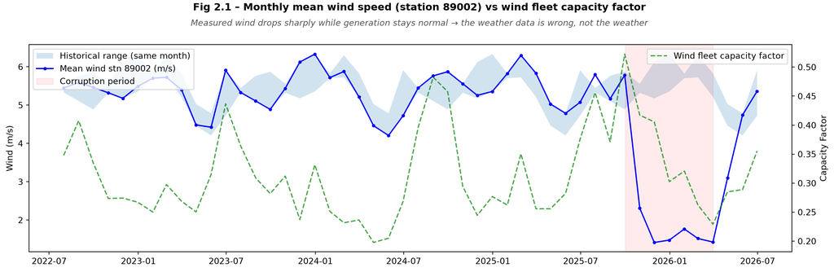

**Table 2.1 – Wind speed vs wind generation: reference (Oct-Mar FY23-25) vs corrupted period**  
*Pearson, Spearman, sd and share of repeated values, by station*

| station | pearson_ref | pearson_bad | spearman_ref | spearman_bad | sd_ref | sd_bad | ties_ref | ties_bad |
| --- | --- | --- | --- | --- | --- | --- | --- | --- |
| 85280 | 0.193 | 0.273 | 0.188 | 0.258 | 2.36 | 0.69 | 0.02 | 0.02 |
| 86338 | 0.342 | 0.373 | 0.329 | 0.343 | 1.49 | 0.42 | 0.04 | 0.04 |
| 89002 | 0.473 | 0.458 | 0.466 | 0.458 | 2.38 | 0.68 | 0.00 | 0.01 |

```
Spearman (89002) in the corrupted period = 0.46: rank information partially preserved -> QM may recover the signal, worth trying before excluding.
```

```python
# =============================================================================
# CELL 2.1 -- Evidence: measured wind drops, generation does not
# Figure: monthly mean wind speed at station 89002 vs its historical range for the same month
# (band), with the wind fleet capacity factor on a second axis. Wind leaving the band while the
# fleet CF stays normal means the weather data is wrong, not the weather.
# Table: how much the corruption damages the link between wind speed and generation.
# =============================================================================


ws_monthly = hh['ws_89002'].resample('ME').mean()
ref = ws_monthly[ws_monthly.index < '2025-07-01']
band = ref.groupby(ref.index.month).agg(['min', 'max'])

# Wind fleet capacity factor (generation / capacity of the farms running in each half-hour)
cap_wind_active_hh = sum(vret_capacity[a] * hh[f'gen_{a}'].notna().astype(float) for a in cfg['wind_assets'])
cf_wind_hh = hh['gen_wind'] / (0.5 * cap_wind_active_hh)
cf_wind_monthly = cf_wind_hh.resample('ME').mean()

fig, ax = plt.subplots(figsize=(14, 4))
band_min = band['min'].reindex(ws_monthly.index.month).values
band_max = band['max'].reindex(ws_monthly.index.month).values
ax.fill_between(ws_monthly.index, band_min, band_max, alpha=0.2, label='Historical range (same month)')
ax.plot(ws_monthly, 'b-o', ms=3, label='Mean wind stn 89002 (m/s)')
ax.axvspan(pd.Timestamp('2025-10-01'), pd.Timestamp('2026-03-31'), color='red', alpha=0.08, label='Corruption period')
ax2 = ax.twinx()
ax2.plot(cf_wind_monthly, 'g--', alpha=0.7, label='Wind fleet capacity factor')
ax.legend(loc='upper left'); ax2.legend(loc='upper right')
ax.set_ylabel('Wind (m/s)'); ax2.set_ylabel('Capacity Factor')
fig.tight_layout()
add_titles(fig, 'Fig 2.1 – Monthly mean wind speed (station 89002) vs wind fleet capacity factor',
           'Measured wind drops sharply while generation stays normal → the weather data is wrong, not the weather')
display(fig)
plt.close(fig)

# ── Wind speed vs generation: reference vs corrupted period, by station ──
# Spearman is rank-based (blind to monotonic squashing). If it stays high, the rank order
# survives and QM can restore the amplitude. 'ties' = share of half-hours that repeat the
# previous value (a sign of smoothing).
def diag(ws, gen, mask):
    """Pearson, Spearman, sd and share of repeated values of ws, and the link with gen."""
    d = pd.DataFrame({'ws': ws[mask], 'gen': gen[mask]}).dropna()
    if len(d) < 10:
        return {'pearson': np.nan, 'spearman': np.nan, 'n': len(d), 'sd': np.nan, 'ties': np.nan}
    return {
        'pearson':  float(round(d['ws'].corr(d['gen']), 3)),
        'spearman': float(round(d['ws'].corr(d['gen'], method='spearman'), 3)),
        'n': len(d),
        'sd':    float(round(d['ws'].std(), 2)),
        'ties':  float(round((d['ws'].diff() == 0).mean(), 2)),   # repeated values -> smoothing signal
    }

idx = hh.index
bad_mask = (idx >= '2025-10-07') & (idx < '2026-04-01')                  # corruption window (starts 07/10, see §3.2)
ref_mask = (idx < '2025-07-01') & idx.month.isin([10, 11, 12, 1, 2, 3])  # same Oct-Mar months, prior years

rows = []
for stn in cfg['station_ids']:
    r = diag(hh[f'ws_{stn}'], hh['gen_wind'], ref_mask)
    b = diag(hh[f'ws_{stn}'], hh['gen_wind'], bad_mask)
    rows.append({'station': stn,
                 'pearson_ref': r['pearson'], 'pearson_bad': b['pearson'],
                 'spearman_ref': r['spearman'], 'spearman_bad': b['spearman'],
                 'sd_ref': r['sd'], 'sd_bad': b['sd'],
                 'ties_ref': r['ties'], 'ties_bad': b['ties']})
summary = pd.DataFrame(rows).set_index('station')
table_title('Table 2.1 – Wind speed vs wind generation: reference (Oct-Mar FY23-25) vs corrupted period',
            'Pearson, Spearman, sd and share of repeated values, by station')
display(summary)

# Verdict: QM can only work if the rank information survived
sp_89002 = summary.loc[89002, 'spearman_bad']
if sp_89002 < 0.35:
    print(f'Spearman (89002) in the corrupted period = {sp_89002:.2f}: rank information LOST -> '
          'QM cannot recover the signal (options: ERA5 reanalysis, or exclude the period).')
else:
    print(f'Spearman (89002) in the corrupted period = {sp_89002:.2f}: rank information partially '
          'preserved -> QM may recover the signal, worth trying before excluding.')
```